# Feature Engineering & EDA Assignment 7

### Section 4.3: Autoencoder

#### What is Autoencoder?

- Autoencoder is a special type of nerual network that copies the input values to the output values. It is categorized as unsupervised learning and it focuses on studying the hidden layer neurons. If the number of neurons in the hidden layers is less than that of the input layers, the hidden layers will extract the essential information of the input values. This condition forces the hidden layers to learn the most patterns of the data and ignore the “noises”. So in an autoencoder model, the hidden layers must have fewer dimensions than those of the input or output layers. If the number of neurons in the hidden layers is more than those of the input layers, the neural network will be given too much capacity to learn the data. In an extreme case, it could just simply copy the input to the output values, including noises, without extracting any essential information.
- Autoencoder performs non-linear transformation of dimension reduction, works better than PCA when the data problems are complex and non-linear. Once the main patterns are identified after reduce the dimensionality, the outliers are revealed.
- The larger the outlier score, the more likely the data point is an outlier.
- Once determine a reasonable boundary of outlier score, can group the data into normal and abnormal cluster to find out the anomalies.

#### Modeling Process

- aggreagte 5 autoencoder models with different hidden_neurons to achieve model stability and reduce overfitting risk

```python
from pyod.models.auto_encoder import AutoEncoder
from pyod.models.combination import aom, moa, average, maximization

# Test a range of hidden_neurons
n_clf = 5
neurons_list = [[25, 2, 2, 25],[25, 10, 2, 10, 25],[30, 15, 10, 2, 10, 15, 30],[50,25,10,5,10,25,50],[75,30,15,5,15,30,75]]
# Just prepare data frames so we can store the model results
train_scores = np.zeros([X_train.shape[0], n_clf])
test_scores = np.zeros([X_test.shape[0], n_clf])
# Modeling
for i in range(n_clf):
    k = neurons_list[i]
    encoder = AutoEncoder(hidden_neurons = k, random_state = 0)
    encoder.fit(X_train_norm)

    # Store the results in each column:
    train_scores[:, i] = encoder.decision_scores_
    test_scores[:, i] = encoder.decision_function(X_test_norm)
# Decision scores have to be normalized before combination
train_scores_norm, test_scores_norm = standardizer(train_scores,test_scores)
```

[output not shown]

[output cut: 165 more lines]

[output not shown]

- combination by average

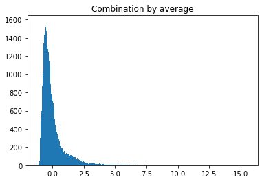

```python
# Combination by average
y_by_average = average(test_scores_norm)
import matplotlib.pyplot as plt
plt.hist(y_by_average, bins='auto') # arguments are passed to np.histogram
plt.title("Combination by average")
plt.show()
```

cluster groups (normal vs abnormal) by the boundary of outlier score of 3.

```python
df_test_avg = X_test.copy()
df_test_avg['y_by_average_score'] = y_by_average
df_test_avg['y_by_average_cluster'] = np.where(df_test_avg['y_by_average_score']<3, 0, 1)
df_test_avg['y_by_average_cluster'].value_counts()
```

```
0    31965
1      648
Name: y_by_average_cluster, dtype: int64
```

The combination by average model identifies 648 data points that have the outlier scores higher than 3

Below is the summary statistics of the two clusters with each feature score

```python
df_test_avg.groupby("y_by_average_cluster").mean()
```

| y_by_average_cluster | drg_avg_ratio_amount | drg_median_ratio_amount | drg_state_avg_ratio_amount | drg_state_median_ratio_amount | drg_state_city_avg_ratio_amount | drg_state_city_median_ratio_amount | hrr_avg_ratio_amount | hrr_median_ratio_amount | drg_hrr_avg_ratio_amount | drg_hrr_median_ratio_amount | y_by_average_score |
| --- | --- | --- | --- | --- | --- | --- | --- | --- | --- | --- | --- |
| 0 | 0.981640 | 1.071261 | 0.984027 | 1.037976 | 0.992717 | 1.000209 | 0.978037 | 1.328645 | 0.987412 | 1.023941 | -0.088440 |
| 1 | 1.844274 | 2.015882 | 1.731640 | 1.862454 | 1.339044 | 1.424982 | 2.191823 | 3.011273 | 1.570776 | 1.695876 | 4.267252 |

The average statistics of the abnormal cluster are much higher than the normal cluster, so those providers in the cluster deserve careful inspection.

- combination by maximum of maximum

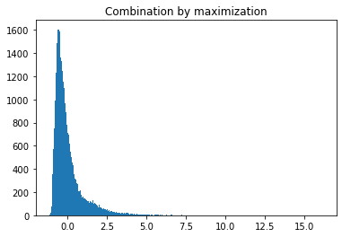

```python
# Combination by mom
y_by_mom = maximization(test_scores_norm)
import matplotlib.pyplot as plt
plt.hist(y_by_mom, bins='auto') # arguments are passed to np.histogram
plt.title("Combination by maximization")
plt.show()
```

cluster groups (normal vs abnormal) by the boundary of outlier score of 3.

```python
df_test_mom = X_test.copy()
df_test_mom['y_by_mom_score'] = y_by_mom
df_test_mom['y_by_mom_cluster'] = np.where(df_test_mom['y_by_mom_score']<3, 0, 1)
df_test_mom['y_by_mom_cluster'].value_counts()
```

```
0    31941
1      672
Name: y_by_mom_cluster, dtype: int64
```

Below is the summary statistics of the two clusters with each feature score

```python
df_test_mom.groupby("y_by_mom_cluster").mean()
```

| y_by_mom_cluster | drg_avg_ratio_amount | drg_median_ratio_amount | drg_state_avg_ratio_amount | drg_state_median_ratio_amount | drg_state_city_avg_ratio_amount | drg_state_city_median_ratio_amount | hrr_avg_ratio_amount | hrr_median_ratio_amount | drg_hrr_avg_ratio_amount | drg_hrr_median_ratio_amount | y_by_mom_score |
| --- | --- | --- | --- | --- | --- | --- | --- | --- | --- | --- | --- |
| 0 | 0.981252 | 1.070841 | 0.983696 | 1.037615 | 0.992583 | 1.000052 | 0.976563 | 1.326635 | 0.987161 | 1.023657 | -0.065370 |
| 1 | 1.831913 | 2.002128 | 1.720677 | 1.850187 | 1.333045 | 1.417257 | 2.218544 | 3.046700 | 1.561864 | 1.685392 | 4.265046 |

The average statistics of the abnormal cluster are much higher than the normal cluster, so those providers in the cluster deserve careful inspection.

- combination by average of maximum

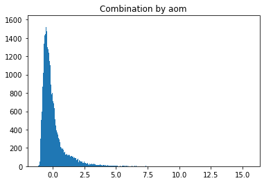

```python
# Combination by aom
y_by_aom = aom(test_scores_norm, n_buckets = 5, random_state = 0)
import matplotlib.pyplot as plt
plt.hist(y_by_aom, bins='auto') # arguments are passed to np.histogram
plt.title("Combination by aom")
plt.show()
```

cluster groups (normal vs abnormal) by the boundary of outlier score of 3.

```python
df_test_aom = X_test.copy()
df_test_aom['y_by_aom_score'] = y_by_aom
df_test_aom['y_by_aom_cluster'] = np.where(df_test_aom['y_by_aom_score']<3, 0, 1)
df_test_aom['y_by_aom_cluster'].value_counts()
```

```
0    31965
1      648
Name: y_by_aom_cluster, dtype: int64
```

Below is the summary statistics of the two clusters with each feature score

```python
df_test_aom.groupby("y_by_aom_cluster").mean()
```

| y_by_aom_cluster | drg_avg_ratio_amount | drg_median_ratio_amount | drg_state_avg_ratio_amount | drg_state_median_ratio_amount | drg_state_city_avg_ratio_amount | drg_state_city_median_ratio_amount | hrr_avg_ratio_amount | hrr_median_ratio_amount | drg_hrr_avg_ratio_amount | drg_hrr_median_ratio_amount | y_by_aom_score |
| --- | --- | --- | --- | --- | --- | --- | --- | --- | --- | --- | --- |
| 0 | 0.981640 | 1.071261 | 0.984027 | 1.037976 | 0.992717 | 1.000209 | 0.978037 | 1.328645 | 0.987412 | 1.023941 | -0.088440 |
| 1 | 1.844274 | 2.015882 | 1.731640 | 1.862454 | 1.339044 | 1.424982 | 2.191823 | 3.011273 | 1.570776 | 1.695876 | 4.267252 |

The average statistics of the abnormal cluster are much higher than the normal cluster, so those providers in the cluster deserve careful inspection.

- combination by maximum of average

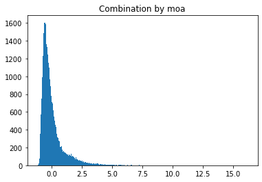

```python
# Combination by moa
y_by_moa = moa(test_scores_norm, n_buckets = 5, random_state = 0)
import matplotlib.pyplot as plt
plt.hist(y_by_moa, bins='auto') # arguments are passed to np.histogram
plt.title("Combination by moa")
plt.show()
```

cluster groups (normal vs abnormal) by the boundary of outlier score of 3.

```python
df_test_moa = X_test.copy()
df_test_moa['y_by_moa_score'] = y_by_moa
df_test_moa['y_by_moa_cluster'] = np.where(df_test_moa['y_by_moa_score']<3, 0, 1)
df_test_moa['y_by_moa_cluster'].value_counts()
```

```
0    31941
1      672
Name: y_by_moa_cluster, dtype: int64
```

Below is the summary statistics of the two clusters with each feature score

```python
df_test_moa.groupby("y_by_moa_cluster").mean()
```

| y_by_moa_cluster | drg_avg_ratio_amount | drg_median_ratio_amount | drg_state_avg_ratio_amount | drg_state_median_ratio_amount | drg_state_city_avg_ratio_amount | drg_state_city_median_ratio_amount | hrr_avg_ratio_amount | hrr_median_ratio_amount | drg_hrr_avg_ratio_amount | drg_hrr_median_ratio_amount | y_by_moa_score |
| --- | --- | --- | --- | --- | --- | --- | --- | --- | --- | --- | --- |
| 0 | 0.981252 | 1.070841 | 0.983696 | 1.037615 | 0.992583 | 1.000052 | 0.976563 | 1.326635 | 0.987161 | 1.023657 | -0.065370 |
| 1 | 1.831913 | 2.002128 | 1.720677 | 1.850187 | 1.333045 | 1.417257 | 2.218544 | 3.046700 | 1.561864 | 1.685392 | 4.265046 |

The average statistics of the abnormal cluster are much higher than the normal cluster, so those providers in the cluster deserve careful inspection.

```python
# create a new dataframe for abnromal data cluster for further exploration
outliers = df_test_avg[df_test_avg['y_by_average_cluster'] == 1]
outl_df = pd.merge(data, outliers, left_index = True, right_index = True)
outl_df.head()
```

|  | DRG | Provider_Id | Provider_Name | Provider_StreetAddress | Provider_City | Provider_State | Provider_Zipcode | Hospital_referral_region_desp | Total_Discharges | Average_Total_Payments | ... | drg_state_avg_ratio_amount | drg_state_median_ratio_amount | drg_state_city_avg_ratio_amount | drg_state_city_median_ratio_amount | hrr_avg_ratio_amount | hrr_median_ratio_amount | drg_hrr_avg_ratio_amount | drg_hrr_median_ratio_amount | y_by_average_score | y_by_average_cluster |
| --- | --- | --- | --- | --- | --- | --- | --- | --- | --- | --- | --- | --- | --- | --- | --- | --- | --- | --- | --- | --- | --- |
| 755 | 039 - EXTRACRANIAL PROCEDURES W/O CC/MCC | 360059 | METRO HEALTH MEDICAL CENTER | 2500 METROHEALTH DRIVE | CLEVELAND | OH | 44109 | OH - Cleveland | 12 | 9506.58 | ... | 1.678649 | 1.777887 | 1.365272 | 1.460607 | 1.115885 | 1.536648 | 1.676181 | 1.784044 | 3.325320 | 1 |
| 1207 | 057 - DEGENERATIVE NERVOUS SYSTEM DISORDERS W/... | 50599 | UNIVERSITY OF CALIFORNIA DAVIS MEDICAL CENTER | 2315 STOCKTON BOULEVARD | SACRAMENTO | CA | 95817 | CA - Sacramento | 22 | 12360.90 | ... | 1.530748 | 1.689677 | 1.276121 | 1.276121 | 1.033859 | 1.445429 | 1.613316 | 1.834124 | 3.249646 | 1 |
| 2174 | 057 - DEGENERATIVE NERVOUS SYSTEM DISORDERS W/... | 450289 | HARRIS COUNTY HOSPITAL DISTRICT | 2525 HOLLY HALL | HOUSTON | TX | 77054 | TX - Houston | 16 | 9726.62 | ... | 1.694381 | 1.798626 | 1.502801 | 1.712449 | 1.060458 | 1.471904 | 1.480180 | 1.787112 | 4.073275 | 1 |
| 2480 | 064 - INTRACRANIAL HEMORRHAGE OR CEREBRAL INFA... | 50454 | UCSF MEDICAL CENTER | 505 PARNASSUS AVE, BOX 0296 | SAN FRANCISCO | CA | 94143 | CA - San Francisco | 53 | 30412.15 | ... | 1.833694 | 1.984117 | 1.220723 | 1.337956 | 2.005571 | 2.730976 | 1.315682 | 1.398493 | 3.790312 | 1 |
| 2589 | 064 - INTRACRANIAL HEMORRHAGE OR CEREBRAL INFA... | 100022 | JACKSON MEMORIAL HOSPITAL | 1611 NW 12TH AVE | MIAMI | FL | 33136 | FL - Miami | 55 | 26157.76 | ... | 2.367860 | 2.582626 | 1.619834 | 1.806227 | 2.572330 | 3.541316 | 1.788899 | 1.817781 | 6.579722 | 1 |

5 rows × 24 columns

## Section 5: Summary & Insights

This project is about Healthcare Fraud Detection. I conduct an Exploratory Data Analysis on the provided dataset and create 10 features to detect any hospital that may abuse the resources compared to the peers.

From the EDA, I found out that 75% of average Medicare payment is under 10,000 dollar, while some high charges are over 150,000 dollars. High population states also have the highest number of hospital divisions, such as California, Texas, and Florida. Long hour and complex surgeries are expensive and simple diagnosis and treatment is cheaper.

Based on the insights gathered from exploratory data analysis, I then created the features to detect healthcare resource abuse activities. I use grouping aggregation and ratios to create features, based on different treatment categories, the hospital state / city, and the hospital referral regions (geographic delineations created to clearly define unique healthcare market regions). The higher the ratio, the higher the likelihood of the Medicare Payment being fraudelent.

Then using the two unsupervised machine learning techniques, I build two models to detect the healthcare resource abuse activities using the 10 derived features and group the data points into two clusters (one is normal data and the other is abnormal outliers). Before modeling, split the train and test by 80/20 and standardize the data.

For Histogram-based Outlier Detection model, I aggregate 15 hbos models with different number of bins to achieve model stability and reduce risk of overfitting. I use 4 methods to compute the outliers scores, they are: average method, maximum of maximum, average of maximum, and maximum of average. Using boundary outlier score of 3, each model identifies some outlier data point. The average statisics of the abnormal cluster from all models are much higher than the normal cluster, so those providers in the cluster deserve careful inspection. And the derived features are meaningful in detecting the outliers because the average statistics of the two clusters are different.

For Principal Component Analysis, it is a dimension reduction technique, and anomaly detection is a byproduct of the technique. I build the PCA model on training data and apply the model to test dataset. The larger the outlier score, the higher the likelihood of that activities is abnormal. Using boundary outlier score of 3, the pca model identifies 675 outliers in the test dataset. The average statisics of the abnormal cluster from the pca model are much higher than the normal cluster, so those providers in the cluster deserve careful inspection. And the derived features are meaningful in detecting the outliers because the average statistics of the two clusters are different.

##### Update

I build two unsupervised machine learning model to detect the healthcare resource abuse activities using the 10 derived features and group the data points into two clusters (one is normal data and the other is abnormal outliers). Before modeling, split the train and test by 80/20 and standardize the data.

For Isolated Forest model, I aggregate 10 iforest models with different max_samples to achieve model stability and reduce risk of overfitting. I use 4 methods to compute the outliers scores, they are: average method, maximum of maximum, average of maximum, and maximum of average. Using boundary outlier score of 3, each model identifies some outlier data point. The average statisics of the abnormal cluster from all models are much higher than the normal cluster, so those providers in the cluster deserve careful inspection. And the derived features are meaningful in detecting the outliers because the average statistics of the two clusters are different.

For autoencoder mode, I aggregate 5 models with different hidden layer neurons to achieve model stability and reduce risk of overfitting. I use 4 methods to compute the outliers scores, they are: average method, maximum of maximum, average of maximum, and maximum of average. Using boundary outlier score of 3, each model identifies some outlier data point. The average statisics of the abnormal cluster from all models are much higher than the normal cluster, so those providers in the cluster deserve careful inspection. And the derived features are meaningful in detecting the outliers because the average statistics of the two clusters are different.